# Social Survey 2010

Joseph Nielsen

Fall 2018

# Introduction

Use the data from the 2010 general social survey to explore whether belief in continental drift (condrift), views on capitol punishment (cappun), and race (race) are independent of each other.

# Methods

We used the data from alldata to get our statistics. Then we ran multipe tests to analyze the variables given. We used a bar graph for each of the tests; Race vs condrift, rave vs cappun, and cappun vs condrift. Then we ran many statstical tests. We did a basic statstical test on each and a Chi-Square test on each. This gives us enough infoprmation to come to a conclusion ofr each qeustion.  
#Results

```r
alldata <- read.csv(file="gss2010.csv", header=TRUE)
#names(alldata)
```

## Descriptive Results

### Graphical Descriptive Results

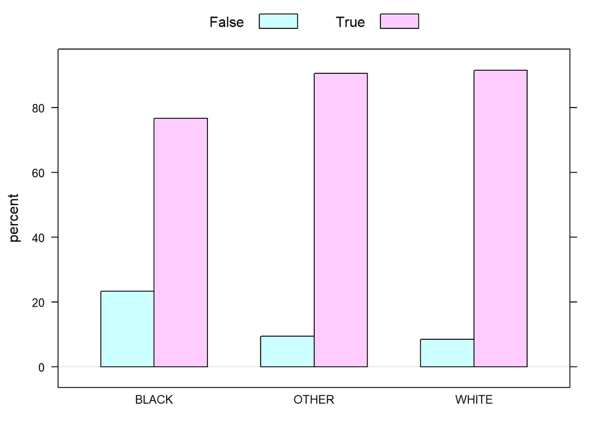

```r
barchartGC(~race+condrift, data=alldata, type = "percent")
```

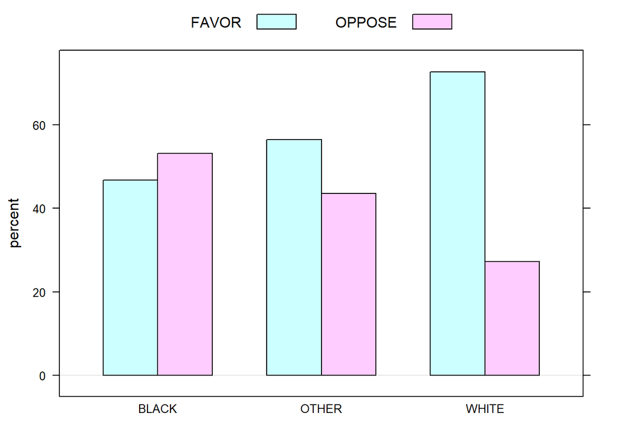

```r
barchartGC(~race+cappun, data=alldata, type = "percent")
```

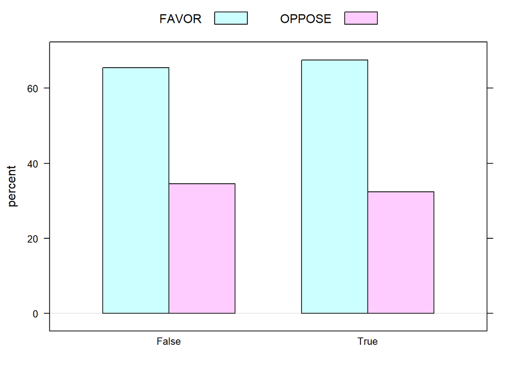

```r
barchartGC(~condrift +cappun, data=alldata, type = "percent")
```

### Numerical Descriptive Results

```r
tab = xtabs(~race+condrift, data=alldata)
rowPerc(tab)
```

```
##        condrift
## race     False   True  Total
##   BLACK  23.30  76.70 100.00
##   OTHER   9.46  90.54 100.00
##   WHITE   8.42  91.58 100.00
```

```r
tab2 = xtabs(~race+cappun, data=alldata)
rowPerc(tab2)
```

```
##        cappun
## race     FAVOR OPPOSE  Total
##   BLACK  46.79  53.21 100.00
##   OTHER  56.47  43.53 100.00
##   WHITE  72.74  27.26 100.00
```

```r
tab3 = xtabs(~condrift+cappun, data=alldata)
rowPerc(tab3)
```

```
##         cappun
## condrift  FAVOR OPPOSE  Total
##    False  65.48  34.52 100.00
##    True   67.57  32.43 100.00
```

## Inferential Results

```
## Pearson's Chi-squared test
##
## Observed Counts:
##        condrift
## race    False True
##   BLACK    24   79
##   OTHER     7   67
##   WHITE    55  598
##
## Counts Expected by Null:
##        condrift
## race    False   True
##   BLACK 10.67  92.33
##   OTHER  7.67  66.33
##   WHITE 67.66 585.34
##
## Contributions to the chi-square statistic:
##        condrift
## race    False  True
##   BLACK 16.64  1.92
##   OTHER  0.06  0.01
##   WHITE  2.37  0.27
##
##
## Chi-Square Statistic = 21.2753
## Degrees of Freedom of the table = 2
## P-Value = 0
```

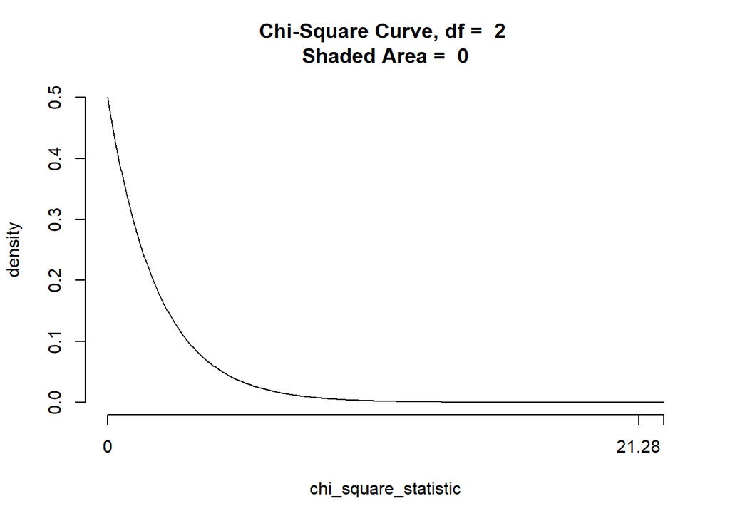

```r
chisqtestGC(~race+condrift, data=alldata, graph = TRUE)
```

```
## Pearson's Chi-squared test
##
## Observed Counts:
##        cappun
## race    FAVOR OPPOSE
##   BLACK   131    149
##   OTHER    96     74
##   WHITE  1070    401
##
## Counts Expected by Null:
##        cappun
## race     FAVOR OPPOSE
##   BLACK 189.05  90.95
##   OTHER 114.78  55.22
##   WHITE 993.17 477.83
##
## Contributions to the chi-square statistic:
##        cappun
## race    FAVOR OPPOSE
##   BLACK 17.82  37.05
##   OTHER  3.07   6.39
##   WHITE  5.94  12.35
##
##
## Chi-Square Statistic = 82.6238
## Degrees of Freedom of the table = 2
## P-Value = 0
```

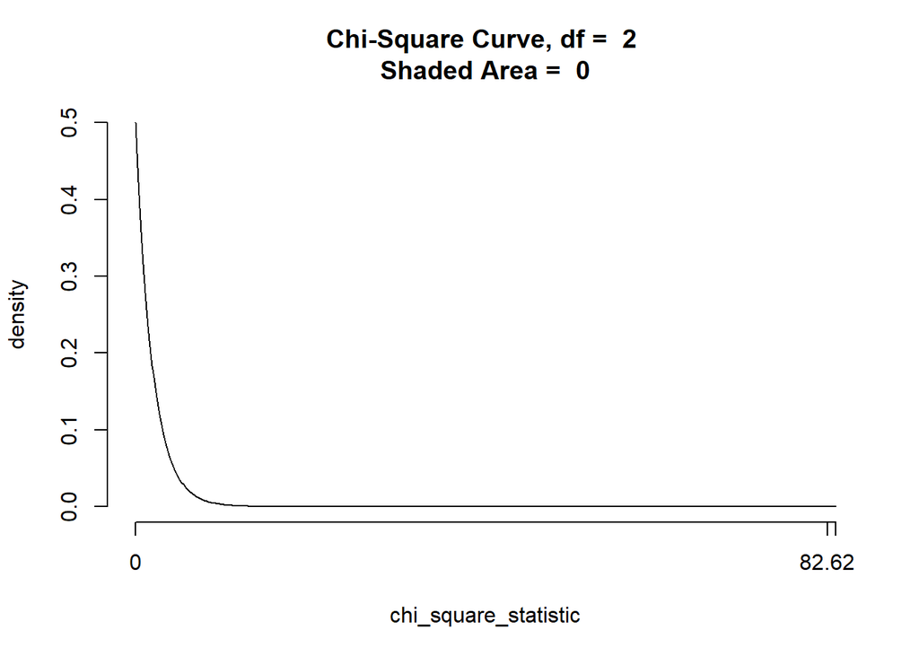

```r
chisqtestGC(~race+cappun, data=alldata, graph = TRUE)
```

```
## Pearson's Chi-squared test with Yates' continuity correction
##
## Observed Counts:
##         cappun
## condrift FAVOR OPPOSE
##    False    55     29
##    True    473    227
##
## Counts Expected by Null:
##         cappun
## condrift  FAVOR OPPOSE
##    False  56.57  27.43
##    True  471.43 228.57
##
## Contributions to the chi-square statistic:
##         cappun
## condrift FAVOR OPPOSE
##    False  0.04   0.09
##    True   0.01   0.01
##
##
## Chi-Square Statistic = 0.0696
## Degrees of Freedom of the table = 1
## P-Value = 0.7919
```

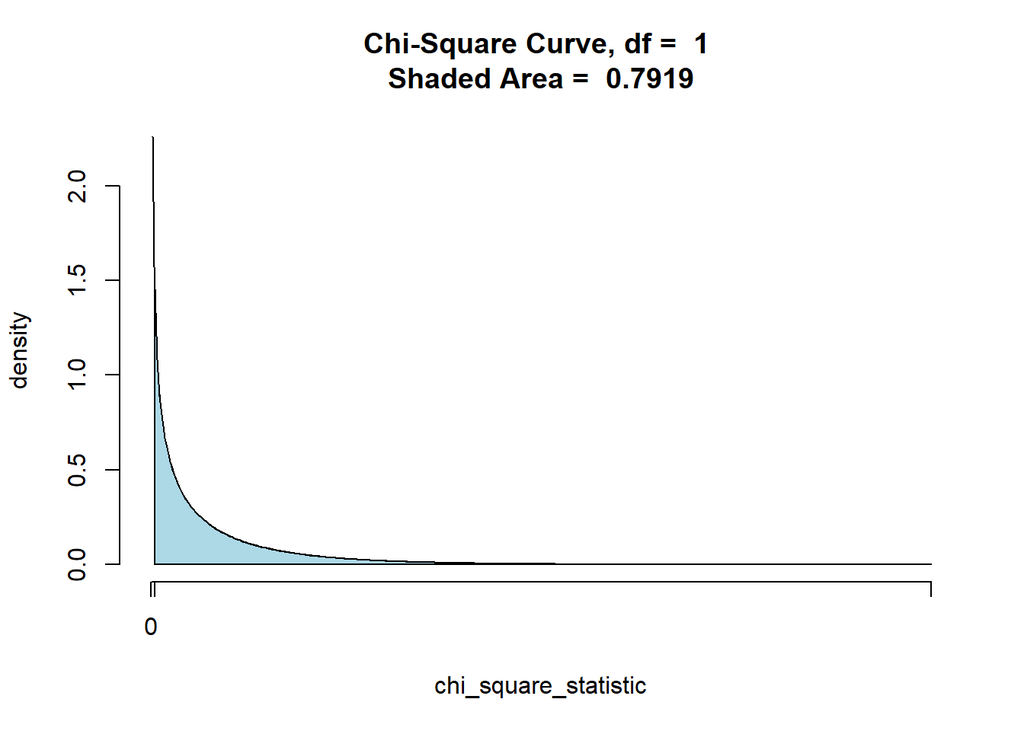

```r
chisqtestGC(~condrift+cappun, data=alldata, graph = TRUE)
```

# Discussion and Conclusion

Race Vs Condrift  
Just from looking at the bar charts one can see that most whites and other believe that continantial drift is true. While in the black section a higher precent of people that believe that continantial dirft is false. Then looking at the basic statstical results it shows that 23.3% black people found continantail drift to be false while less than 10% found it false in the other two races. The Chi-square calculated value is greater than the chi-square critical value, then we reject our null hypothesis. Meaning that there is a relationship between race and condrift.

Race VS Cappun  
The race that favors capital punishment the most is white people at 72.7%. While black people oppose it the mostbecause on;y 46.8 favor it. While others is split about with 56.5% favor it. The Chi-square calculated value is greater than the chi-square critical value, then we reject our null hypothesis. Meaning that there is a relationship between race and Cappun.

Condrift Vs Cappun  
I dont really see any relationships here because either way if you think continantial drift is true or false about 66% favor capital punishment either way so i dont know what to take from this. Chi-square calculated value is less than the chi-square critical value, then we accept the null hypothesis. Meaning that there is no relationship between the two.